# SPiCT for *Nephrops* stocks with UWTV surveys

- Show All Code
- Hide All Code
- View Source

Comparative overview: acceptance, parameters, trends, and comparison with the ICES Category 1 assessments

Published

November 21, 2026

**Important**

This is an exploratory comparison. SPiCT was applied with one generic configuration to stocks that ICES assesses with the UWTV-based Category 1 method. The results are **not** an alternative basis for advice. Each stock would need a benchmark (stock-specific priors, index treatment, catch history) before a SPiCT assessment could be considered.

# 1 Scope

The stocks are the 16 ICES Category 1 *Nephrops* stocks with a UWTV survey and a UWTV-based assessment, as listed in WGNEPH 2025 (ICES 2026). Inputs are the 2026 SAG records, so the last data point is the 2026 UWTV survey. The model configuration follows the accepted FU32 SPiCT assessment (`knowledge/spict_conventions.md`). Summaries are available for 16 stocks.

**Stocks with tuned configuration**

With the generic configuration, SPiCT does not converge for 2 of 16 stocks (FU 3-4 †, FU 12 †). For FU 3-4 † and FU 12 †, the B0/K prior was set to 0.75 (SD 0.25) so that the model converges (project lead’s decision, see knowledge/decisions.md). Their results are reported and marked † and “TUNED B0/K” throughout. A prior chosen for convergence is tuning, not external information: these stocks are **not assessable with the generic configuration**, and their results carry less weight than those of the other stocks.

```r
bind_rows(lapply(S, \(x) x$meta)) |>
  transmute(FU = sub("^FU ", "", lab(stock)), Area = area, Ecoregion = ecoregion,
            Configuration = cfg_label(stock),
            `Generic config. converges` = ifelse(cfg_tab$generic_converged[match(stock, cfg_tab$stock)], "yes", "NO"),
            Catch = paste0(catch_start, "–", catch_end),
            UWTV = paste0(index_start, "–", index_end), `N surveys` = n_index,
            `Mean CV (%)` = round(100 * mean_index_cv, 1),
            `Discard survival (%)` = 100 * discard_survival,
            `Imputed discard years` = n_imputed_discards,
            `MSY Btrigger` = ifelse(is.na(MSYBtrigger), "none", "yes"),
            `FMSY proxy HR (%)` = FMSY_HR) |>
  kbl(caption = "Stocks, data coverage, and Category 1 reference points (SAG).") |>
  kable_styling(bootstrap_options = c("striped", "condensed"), font_size = 11)
```

Stocks, data coverage, and Category 1 reference points (SAG).

| FU | Area | Ecoregion | Configuration | Generic config. converges | Catch | UWTV | N surveys | Mean CV (%) | Discard survival (%) | Imputed discard years | MSY Btrigger | FMSY proxy HR (%) |
| --- | --- | --- | --- | --- | --- | --- | --- | --- | --- | --- | --- | --- |
| 3-4 † | Skagerrak and Kattegat | Greater North Sea | TUNED B0/K | NO | 1997–2025 | 2017–2026 | 10 | 5.2 | 25 | 0 | none | 7.90 |
| 6 | Farn Deeps | Greater North Sea | generic | yes | 1981–2025 | 2001–2026 | 26 | 5.0 | 15 | 19 | yes | 8.12 |
| 7 | Fladen Ground | Greater North Sea | generic | yes | 1992–2025 | 1992–2026 | 34 | 7.2 | 25 | 8 | yes | 7.50 |
| 8 | Firth of Forth | Greater North Sea | generic | yes | 1993–2025 | 1993–2026 | 32 | 9.3 | 25 | 0 | yes | 16.30 |
| 9 | Moray Firth | Greater North Sea | generic | yes | 1993–2025 | 1993–2026 | 32 | 14.3 | 25 | 0 | yes | 11.80 |
| 11 | North Minch | West of Scotland | generic | yes | 1981–2025 | 1994–2026 | 31 | 8.3 | 25 | 9 | yes | 10.80 |
| 12 † | South Minch | West of Scotland | TUNED B0/K | NO | 1981–2025 | 1995–2026 | 32 | 10.4 | 25 | 9 | yes | 11.70 |
| 13 | Firth of Clyde and Sound of Jura | West of Scotland | generic | yes | 1981–2025 | 1995–2026 | 25 | 7.4 | 25 | 9 | yes | 15.10 |
| 14 | Irish Sea East | Celtic Seas | generic | yes | 2000–2025 | 2008–2026 | 19 | 10.1 | 10 | 3 | yes | 11.00 |
| 15 | Irish Sea West | Celtic Seas | generic | yes | 1983–2025 | 2003–2026 | 24 | 3.0 | 10 | 3 | yes | 18.20 |
| 16 | Porcupine Bank | Celtic Seas | generic | yes | 1992–2025 | 2012–2026 | 14 | 3.9 | 0 | 0 | yes | 6.20 |
| 17 | Aran grounds | Celtic Seas | generic | yes | 1982–2025 | 2002–2026 | 24 | 5.2 | 25 | 22 | yes | 8.50 |
| 19 | Irish Sea Celtic Sea and SW Ireland | Celtic Seas | generic | yes | 1991–2025 | 2011–2026 | 16 | 14.1 | 25 | 15 | yes | 9.30 |
| 20-21 | Celtic Sea (Labadie Jones Cockburn) | Celtic Seas | generic | yes | 1995–2025 | 2013–2026 | 14 | 4.5 | 25 | 17 | yes | 6.00 |
| 22 | Smalls | Celtic Seas | generic | yes | 1999–2025 | 2006–2026 | 21 | 6.0 | 25 | 4 | yes | 12.80 |
| 23-24 | Bay of Biscay north and central | Bay of Biscay and Iberian Coast | generic | yes | 1996–2025 | 2016–2026 | 11 | 8.9 | 50 | 0 | none | 7.70 |

# 2 Acceptance of the SPiCT assessments

The checklist follows the SPiCT guidelines (`knowledge/acceptance_criteria.md`). The Mohn’s rho verdict uses the shorter-lived bar [−0.22, 0.30] of Hurtado-Ferro et al. (2015). The longer-lived bar [−0.15, 0.20] is shown separately.

```r
acc <- bind_rows(lapply(ok, function(s) S[[s]]$checks |> mutate(stock = s))) |>
  mutate(FU = factor(lab(stock), fu_levels))
acc_wide <- acc |>
  filter(id <= 8) |>
  mutate(v = case_when(is.na(pass) ~ "–", pass ~ "✓", TRUE ~ "✗")) |>
  select(FU, check, v) |>
  pivot_wider(names_from = check, values_from = v)
acc_n <- acc |> filter(id <= 7) |> group_by(FU) |>
  summarise(passed = sum(pass, na.rm = TRUE), evaluated = sum(!is.na(pass)),
            rho_long = any(id == 4 & pass_long %in% TRUE), .groups = "drop") |>
  mutate(accepted = passed == 7 & evaluated == 7)
n_acc <- sum(acc_n$accepted)
```

7 of 16 stocks pass all seven acceptance criteria (1 of them with a tuned B0/K prior; 6 with the generic configuration).

```r
acc_wide |>
  left_join(acc_n |> transmute(FU, `Passed (of 7)` = passed,
                                Accepted = ifelse(accepted, "yes", "no")), by = "FU") |>
  left_join(cfg_tab |> transmute(FU, Configuration = cfg_label(stock)), by = "FU") |>
  relocate(Accepted, Configuration, .after = FU) |>
  arrange(FU) |>
  kbl(caption = "Acceptance checklist by stock (✓ pass, ✗ fail, – not evaluated). Hindcast MASE is supplementary.") |>
  kable_styling(bootstrap_options = c("striped", "condensed"), font_size = 11)
```

Acceptance checklist by stock (✓ pass, ✗ fail, – not evaluated). Hindcast MASE is supplementary.

| FU | Accepted | Configuration | Convergence | Finite variances | OSA residuals | Retrospective pattern | Production curve | Assessment uncertainty | Initial values | Hindcast (supplementary) | Passed (of 7) |
| --- | --- | --- | --- | --- | --- | --- | --- | --- | --- | --- | --- |
| FU 3-4 † | no | TUNED B0/K | ✓ | ✓ | ✓ | ✗ | ✓ | ✗ | ✓ | ✗ | 5 |
| FU 6 | yes | generic | ✓ | ✓ | ✓ | ✓ | ✓ | ✓ | ✓ | ✗ | 7 |
| FU 7 | yes | generic | ✓ | ✓ | ✓ | ✓ | ✓ | ✓ | ✓ | ✓ | 7 |
| FU 8 | yes | generic | ✓ | ✓ | ✓ | ✓ | ✓ | ✓ | ✓ | ✓ | 7 |
| FU 9 | yes | generic | ✓ | ✓ | ✓ | ✓ | ✓ | ✓ | ✓ | ✓ | 7 |
| FU 11 | yes | generic | ✓ | ✓ | ✓ | ✓ | ✓ | ✓ | ✓ | ✗ | 7 |
| FU 12 † | yes | TUNED B0/K | ✓ | ✓ | ✓ | ✓ | ✓ | ✓ | ✓ | ✗ | 7 |
| FU 13 | no | generic | ✓ | ✓ | ✓ | ✓ | ✓ | ✓ | ✗ | ✓ | 6 |
| FU 14 | no | generic | ✓ | ✓ | ✓ | ✗ | ✓ | ✗ | ✓ | ✗ | 5 |
| FU 15 | no | generic | ✓ | ✓ | ✗ | ✗ | ✓ | ✓ | ✓ | ✓ | 5 |
| FU 16 | no | generic | ✓ | ✓ | ✗ | ✓ | ✓ | ✓ | ✓ | ✓ | 6 |
| FU 17 | no | generic | ✓ | ✓ | ✓ | ✗ | ✓ | ✓ | ✗ | ✗ | 5 |
| FU 19 | no | generic | ✓ | ✓ | ✓ | ✓ | ✓ | ✓ | ✗ | ✗ | 6 |
| FU 20-21 | no | generic | ✓ | ✓ | ✗ | ✗ | ✓ | ✗ | ✗ | ✗ | 3 |
| FU 22 | yes | generic | ✓ | ✓ | ✓ | ✓ | ✓ | ✓ | ✓ | ✗ | 7 |
| FU 23-24 | no | generic | ✓ | ✓ | ✓ | ✗ | ✓ | ✓ | ✗ | ✓ | 5 |

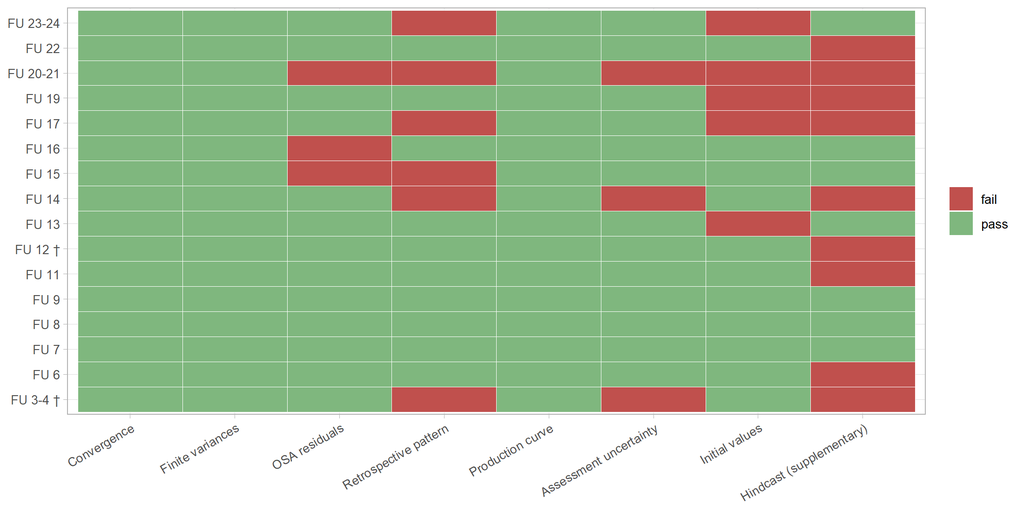

Figure 1: Which criteria fail, by stock.

```r
acc |> filter(id <= 8) |>
  mutate(check = factor(check, unique(acc$check[order(acc$id)])),
         verdict = case_when(is.na(pass) ~ "not evaluated", pass ~ "pass", TRUE ~ "fail")) |>
  ggplot(aes(check, FU, fill = verdict)) +
  geom_tile(colour = "white") +
  scale_fill_manual(values = c(pass = "#7FB77E", fail = "#C0504D", `not evaluated` = "grey80"), name = NULL) +
  labs(x = NULL, y = NULL) + report_theme +
  theme(axis.text.x = element_text(angle = 30, hjust = 1))
```

```r
acc |> filter(id %in% c(3, 4, 5, 6, 8)) |>
  select(FU, check, value) |>
  pivot_wider(names_from = check, values_from = value) |>
  arrange(FU) |>
  kbl(caption = "Values behind the main diagnostic criteria.") |>
  kable_styling(bootstrap_options = c("striped", "condensed"), font_size = 10)
```

Values behind the main diagnostic criteria.

| FU | OSA residuals | Retrospective pattern | Production curve | Assessment uncertainty | Hindcast (supplementary) |
| --- | --- | --- | --- | --- | --- |
| FU 3-4 † | 0 of 6 tests p <= 0.05; min p = 0.063 | B/Bmsy -0.230; F/Fmsy 0.620 | 0.50 | B/Bmsy 0.61; F/Fmsy 1.12 | 1.18 |
| FU 6 | 0 of 6 tests p <= 0.05; min p = 0.157 | B/Bmsy 0.032; F/Fmsy 0.018 | 0.50 | B/Bmsy 0.43; F/Fmsy 0.40 | 1.08 |
| FU 7 | 0 of 6 tests p <= 0.05; min p = 0.270 | B/Bmsy -0.064; F/Fmsy 0.082 | 0.50 | B/Bmsy 0.48; F/Fmsy 0.84 | 0.65 |
| FU 8 | 0 of 6 tests p <= 0.05; min p = 0.289 | B/Bmsy 0.028; F/Fmsy -0.029 | 0.50 | B/Bmsy 0.26; F/Fmsy 0.45 | 0.79 |
| FU 9 | 0 of 6 tests p <= 0.05; min p = 0.318 | B/Bmsy 0.069; F/Fmsy -0.026 | 0.50 | B/Bmsy 0.40; F/Fmsy 0.59 | 0.67 |
| FU 11 | 0 of 6 tests p <= 0.05; min p = 0.181 | B/Bmsy 0.055; F/Fmsy -0.067 | 0.50 | B/Bmsy 0.24; F/Fmsy 0.48 | 1.33 |
| FU 12 † | 0 of 6 tests p <= 0.05; min p = 0.134 | B/Bmsy 0.088; F/Fmsy -0.175 | 0.50 | B/Bmsy 0.25; F/Fmsy 0.58 | 1.14 |
| FU 13 | 0 of 6 tests p <= 0.05; min p = 0.193 | B/Bmsy 0.009; F/Fmsy 0.005 | 0.50 | B/Bmsy 0.25; F/Fmsy 0.52 | 0.62 |
| FU 14 | 0 of 6 tests p <= 0.05; min p = 0.072 | B/Bmsy 0.095; F/Fmsy -0.311 | 0.50 | B/Bmsy 0.47; F/Fmsy 1.77 | 1.99 |
| FU 15 | 1 of 6 tests p <= 0.05; min p = 0.004 | B/Bmsy 0.431; F/Fmsy -0.472 | 0.50 | B/Bmsy 0.76; F/Fmsy 0.87 | 0.84 |
| FU 16 | 1 of 6 tests p <= 0.05; min p = 0.003 | B/Bmsy -0.145; F/Fmsy 0.055 | 0.50 | B/Bmsy 0.85; F/Fmsy 0.92 | 0.59 |
| FU 17 | 0 of 6 tests p <= 0.05; min p = 0.203 | B/Bmsy 0.284; F/Fmsy -0.247 | 0.50 | B/Bmsy 0.47; F/Fmsy 0.62 | 1.09 |
| FU 19 | 0 of 6 tests p <= 0.05; min p = 0.327 | B/Bmsy 0.126; F/Fmsy -0.105 | 0.50 | B/Bmsy 0.45; F/Fmsy 0.47 | 1.12 |
| FU 20-21 | 1 of 6 tests p <= 0.05; min p = 0.009 | B/Bmsy -0.813; F/Fmsy 6.456 | 0.50 | B/Bmsy 0.36; F/Fmsy 1.03 | 2.74 |
| FU 22 | 0 of 6 tests p <= 0.05; min p = 0.203 | B/Bmsy 0.299; F/Fmsy -0.179 | 0.50 | B/Bmsy 0.82; F/Fmsy 0.47 | 1.03 |
| FU 23-24 | 0 of 6 tests p <= 0.05; min p = 0.103 | B/Bmsy 2.057; F/Fmsy -0.606 | 0.50 | B/Bmsy 0.47; F/Fmsy 0.38 | 0.98 |

```r
bind_rows(lapply(ok, function(s) S[[s]]$residuals |> mutate(FU = lab(s)))) |>
  filter(p <= 0.05) |>
  mutate(series = recode(series, C = "catch", I1 = "index", B = "biomass", F = "fishing mortality"),
         p = signif(p, 2)) |>
  arrange(factor(FU, fu_levels)) |>
  kbl(caption = "Residual tests with p <= 0.05. Observation (catch, index) residuals enter acceptance criterion 3; process residuals are reported for information.") |>
  kable_styling(bootstrap_options = c("striped", "condensed"), full_width = FALSE, font_size = 11)
```

Residual tests with p <= 0.05. Observation (catch, index) residuals enter acceptance criterion 3; process residuals are reported for information.

| type | series | test | p | FU |
| --- | --- | --- | --- | --- |
| process | biomass | autocorrelation | 0.0460 | FU 6 |
| process | biomass | autocorrelation | 0.0470 | FU 7 |
| observation | index | normality | 0.0038 | FU 15 |
| process | biomass | normality | 0.0250 | FU 15 |
| observation | catch | normality | 0.0028 | FU 16 |
| process | biomass | autocorrelation | 0.0340 | FU 16 |
| process | biomass | normality | 0.0210 | FU 17 |
| observation | catch | normality | 0.0088 | FU 20-21 |
| process | fishing mortality | normality | 0.0190 | FU 23-24 |

# 3 Estimated parameters

```r
pars <- bind_rows(lapply(ok, function(s) S[[s]]$params |> mutate(stock = s))) |>
  mutate(FU = factor(lab(stock), fu_levels))
pp <- bind_rows(lapply(ok, function(s) S[[s]]$priors |> mutate(stock = s))) |>
  mutate(FU = factor(lab(stock), fu_levels))
```

```r
pars |>
  filter(parameter %in% c("r", "K", "MSY", "Fmsy", "sdb", "sdi", "sdc")) |>
  mutate(txt = ifelse(parameter %in% c("K", "MSY"),
                      sprintf("%s (%s–%s)", signif(est, 3), signif(lo, 2), signif(hi, 2)),
                      sprintf("%.2f (%.2f–%.2f)", est, lo, hi))) |>
  select(FU, parameter, txt) |>
  pivot_wider(names_from = parameter, values_from = txt) |>
  left_join(pars |> distinct(FU, bmsyk), by = "FU") |>
  arrange(FU) |>
  rename(`K (t)` = K, `MSY (t)` = MSY, `BMSY/K` = bmsyk) |>
  mutate(`BMSY/K` = round(`BMSY/K`, 2)) |>
  kbl(caption = "Parameter estimates with 95 % CI. Schaefer shape fixed (BMSY/K = 0.5).") |>
  kable_styling(bootstrap_options = c("striped", "condensed"), font_size = 10)
```

Parameter estimates with 95 % CI. Schaefer shape fixed (BMSY/K = 0.5).

| FU | r | K (t) | MSY (t) | Fmsy | sdb | sdi | sdc | BMSY/K |
| --- | --- | --- | --- | --- | --- | --- | --- | --- |
| FU 3-4 † | 0.55 (0.34–0.91) | 62100 (25000–160000) | 8150 (4200–16000) | 0.27 (0.16–0.45) | 0.16 (0.11–0.22) | 0.08 (0.03–0.19) | 0.10 (0.07–0.14) | 0.5 |
| FU 6 | 0.66 (0.39–1.12) | 21200 (13000–35000) | 3350 (2500–4400) | 0.32 (0.19–0.56) | 0.15 (0.11–0.21) | 0.08 (0.04–0.15) | 0.22 (0.15–0.31) | 0.5 |
| FU 7 | 0.54 (0.36–0.81) | 59400 (35000–1e+05) | 7280 (5000–11000) | 0.26 (0.17–0.39) | 0.20 (0.16–0.26) | 0.07 (0.03–0.16) | 0.12 (0.07–0.19) | 0.5 |
| FU 8 | 0.59 (0.37–0.94) | 19500 (11000–34000) | 2770 (2300–3400) | 0.29 (0.18–0.46) | 0.13 (0.10–0.18) | 0.15 (0.11–0.22) | 0.10 (0.07–0.15) | 0.5 |
| FU 9 | 0.57 (0.36–0.90) | 10300 (6100–17000) | 1400 (1200–1700) | 0.28 (0.17–0.45) | 0.14 (0.10–0.19) | 0.25 (0.18–0.33) | 0.13 (0.09–0.20) | 0.5 |
| FU 11 | 0.61 (0.38–0.97) | 27600 (16000–49000) | 4050 (3200–5100) | 0.30 (0.19–0.48) | 0.14 (0.10–0.19) | 0.15 (0.10–0.21) | 0.10 (0.06–0.14) | 0.5 |
| FU 12 † | 0.60 (0.37–0.96) | 34500 (18000–67000) | 5010 (3400–7500) | 0.30 (0.18–0.48) | 0.12 (0.09–0.17) | 0.28 (0.21–0.37) | 0.07 (0.05–0.11) | 0.5 |
| FU 13 | 0.54 (0.33–0.88) | 45600 (26000–79000) | 5950 (4500–7900) | 0.27 (0.16–0.44) | 0.12 (0.08–0.16) | 0.14 (0.09–0.21) | 0.12 (0.09–0.16) | 0.5 |
| FU 14 | 0.43 (0.28–0.66) | 8470 (1600–45000) | 818 (180–3800) | 0.20 (0.13–0.32) | 0.19 (0.14–0.25) | 0.14 (0.08–0.25) | 0.13 (0.08–0.22) | 0.5 |
| FU 15 | 0.52 (0.32–0.83) | 73700 (45000–120000) | 9260 (7400–12000) | 0.26 (0.16–0.41) | 0.13 (0.09–0.17) | 0.06 (0.03–0.11) | 0.09 (0.07–0.13) | 0.5 |
| FU 16 | 0.44 (0.25–0.77) | 21300 (11000–41000) | 2140 (1400–3200) | 0.21 (0.12–0.38) | 0.19 (0.12–0.28) | 0.05 (0.02–0.16) | 0.11 (0.07–0.18) | 0.5 |
| FU 17 | 0.40 (0.27–0.60) | 8080 (5100–13000) | 760 (570–1000) | 0.19 (0.13–0.29) | 0.15 (0.10–0.22) | 0.18 (0.11–0.27) | 0.31 (0.22–0.43) | 0.5 |
| FU 19 | 0.47 (0.30–0.74) | 7400 (4500–12000) | 824 (630–1100) | 0.23 (0.14–0.37) | 0.15 (0.10–0.22) | 0.22 (0.14–0.32) | 0.14 (0.08–0.24) | 0.5 |
| FU 20-21 | 0.54 (0.29–1.00) | 27100 (13000–57000) | 3420 (2500–4600) | 0.26 (0.14–0.49) | 0.18 (0.12–0.27) | 0.31 (0.20–0.48) | 0.10 (0.06–0.16) | 0.5 |
| FU 22 | 0.50 (0.31–0.79) | 20600 (12000–36000) | 2430 (1600–3700) | 0.24 (0.15–0.39) | 0.14 (0.10–0.20) | 0.15 (0.10–0.22) | 0.20 (0.16–0.26) | 0.5 |
| FU 23-24 | 0.51 (0.32–0.84) | 32100 (19000–54000) | 3990 (3100–5200) | 0.25 (0.15–0.42) | 0.13 (0.09–0.18) | 0.19 (0.12–0.29) | 0.09 (0.06–0.15) | 0.5 |

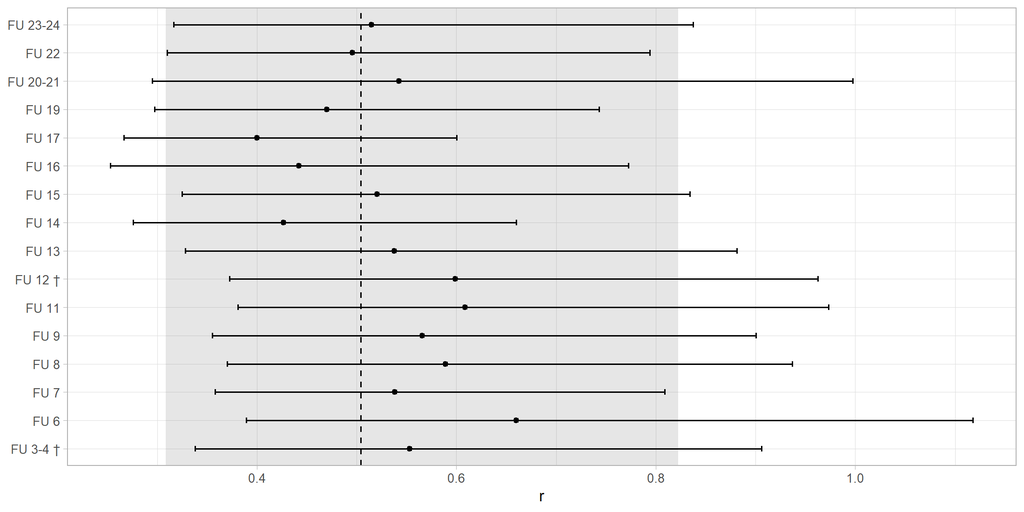

Figure 2: Posterior of r by stock (95 % CI) against the common prior (median and 95 % range shaded). Stocks whose posterior sits on the prior gain little information on productivity from their data.

```r
r_prior <- exp(log(settings$r_median) - 0.5 * settings$r_sd^2 + c(-1.96, 0, 1.96) * settings$r_sd)
pars |> filter(parameter == "r") |>
  ggplot(aes(est, FU)) +
  annotate("rect", xmin = r_prior[1], xmax = r_prior[3], ymin = -Inf, ymax = Inf, alpha = 0.15) +
  geom_vline(xintercept = r_prior[2], linetype = 2) +
  geom_errorbarh(aes(xmin = lo, xmax = hi), height = 0.2) + geom_point() +
  labs(x = "r", y = NULL) + report_theme
```

```r
pp |> filter(parameter %in% c("r", "bkfrac", "sdi")) |>
  select(FU, parameter, sd_ratio, shift_in_prior_sd) |>
  pivot_wider(names_from = parameter, values_from = c(sd_ratio, shift_in_prior_sd)) |>
  arrange(FU) |>
  mutate(across(where(is.numeric), ~round(.x, 2))) |>
  kbl(caption = "Information in the data: posterior/prior SD ratio (near 1: posterior on prior) and shift of the posterior median in prior SDs.") |>
  kable_styling(bootstrap_options = c("striped", "condensed"), font_size = 11)
```

Information in the data: posterior/prior SD ratio (near 1: posterior on prior) and shift of the posterior median in prior SDs.

| FU | sd_ratio_r | sd_ratio_bkfrac | sd_ratio_sdi | shift_in_prior_sd_r | shift_in_prior_sd_bkfrac | shift_in_prior_sd_sdi |
| --- | --- | --- | --- | --- | --- | --- |
| FU 3-4 † | 1.01 | 0.91 | 0.89 | 0.37 | -0.14 | 0.89 |
| FU 6 | 1.08 | 0.82 | 0.67 | 1.08 | -0.38 | 0.84 |
| FU 7 | 0.83 | 0.58 | 0.84 | 0.26 | -0.14 | -0.05 |
| FU 8 | 0.95 | 0.36 | 0.35 | 0.62 | -0.25 | 1.02 |
| FU 9 | 0.95 | 0.53 | 0.31 | 0.46 | 0.28 | 1.09 |
| FU 11 | 0.96 | 0.61 | 0.37 | 0.76 | -0.42 | 1.14 |
| FU 12 † | 0.97 | 0.92 | 0.29 | 0.69 | -0.24 | 1.96 |
| FU 13 | 1.01 | 0.49 | 0.41 | 0.26 | -1.68 | 1.27 |
| FU 14 | 0.89 | 0.87 | 0.55 | -0.67 | 0.37 | 0.71 |
| FU 15 | 0.96 | 0.71 | 0.63 | 0.13 | 0.44 | 1.42 |
| FU 16 | 1.14 | 0.73 | 1.14 | -0.52 | -0.43 | 0.59 |
| FU 17 | 0.83 | 1.04 | 0.44 | -0.93 | -0.16 | 2.42 |
| FU 19 | 0.93 | 0.77 | 0.40 | -0.28 | 0.25 | 0.84 |
| FU 20-21 | 1.24 | 1.16 | 0.45 | 0.29 | -0.02 | 3.86 |
| FU 22 | 0.96 | 0.86 | 0.40 | -0.06 | 0.03 | 1.77 |
| FU 23-24 | 0.99 | 0.71 | 0.45 | 0.09 | 0.17 | 1.47 |

# 4 Stock trends

```r
ts <- bind_rows(lapply(ok, function(s) S[[s]]$timeseries |> mutate(stock = s))) |>
  mutate(FU = factor(lab(stock), fu_levels))
```

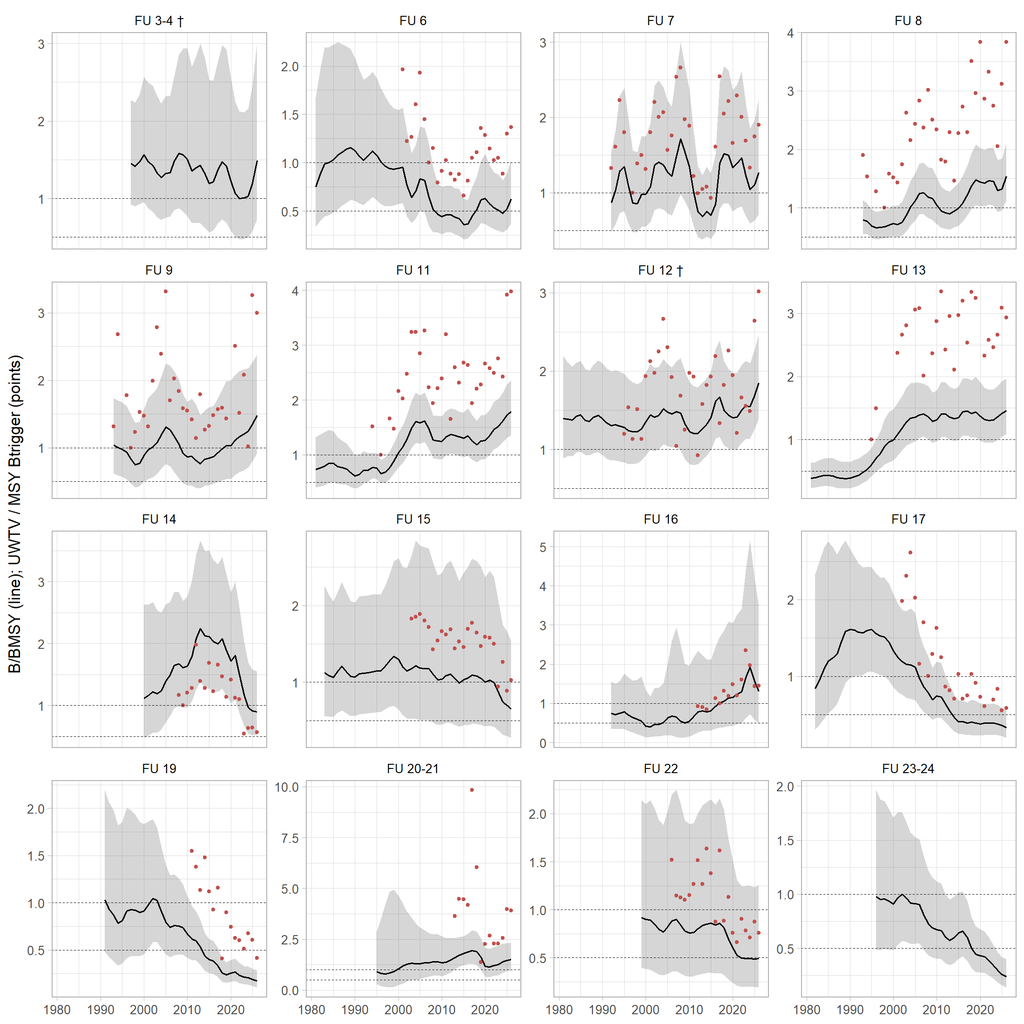

Figure 3: SPiCT B/BMSY (line, 95 % CI) and UWTV abundance / MSY Btrigger (points) by stock. Dashed: B/BMSY = 1 and 0.5.

```r
ts |> filter(year <= settings$sag_year) |>
  ggplot(aes(year)) +
  geom_ribbon(aes(ymin = BBmsy_lo, ymax = BBmsy_hi), alpha = 0.2) +
  geom_line(aes(y = BBmsy)) +
  geom_point(aes(y = B_Btrigger_ices), colour = "#C0504D", size = 0.9, na.rm = TRUE) +
  geom_hline(yintercept = c(0.5, 1), linetype = 2, linewidth = 0.3) +
  facet_wrap(~FU, scales = "free_y", ncol = 4) +
  labs(x = NULL, y = "B/BMSY (line); UWTV / MSY Btrigger (points)") + report_theme
```

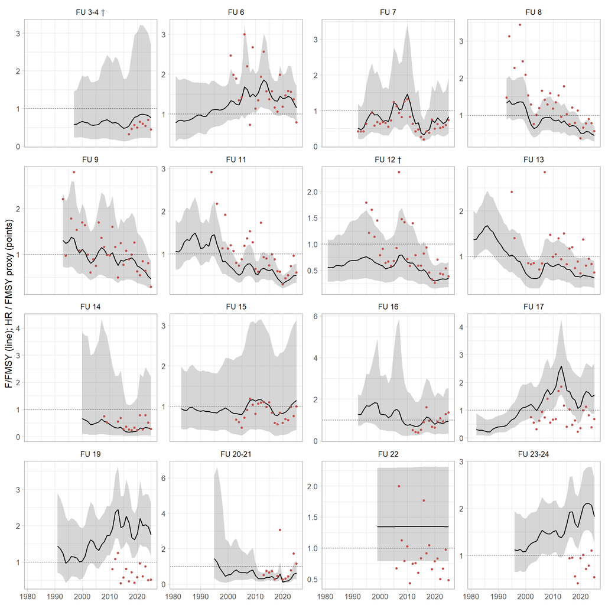

Figure 4: SPiCT F/FMSY (line, 95 % CI) and Category 1 HR / FMSY proxy (points). Dashed: 1.

```r
ts |> filter(year < settings$sag_year) |>
  ggplot(aes(year)) +
  geom_ribbon(aes(ymin = FFmsy_lo, ymax = FFmsy_hi), alpha = 0.2) +
  geom_line(aes(y = FFmsy)) +
  geom_point(aes(y = HR_FMSY_ices), colour = "#C0504D", size = 0.9, na.rm = TRUE) +
  geom_hline(yintercept = 1, linetype = 2, linewidth = 0.3) +
  facet_wrap(~FU, scales = "free_y", ncol = 4) +
  labs(x = NULL, y = "F/FMSY (line); HR / FMSY proxy (points)") + report_theme
```

# 5 Comparison with the ICES Category 1 assessments

The two assessments use different kinds of reference point. MSY Btrigger in Category 1 is mostly the lowest observed abundance (Bloss), and the FMSY proxy is a per-recruit harvest rate. SPiCT estimates production-model BMSY and FMSY. The comparison is therefore made on **trends** (correlations over the survey years) and on **status classifications**, not on the size of the ratios.

```r
cmp <- bind_rows(lapply(ok, function(s) {
  x <- S[[s]]; t <- x$timeseries; st <- x$status
  last_hr <- t |> filter(!is.na(HR_FMSY_ices)) |> slice_tail(n = 1)
  last_b  <- t |> filter(!is.na(index)) |> slice_tail(n = 1)
  tibble(
    stock = s, FU = lab(s),
    cor_B = suppressWarnings(cor(log(t$BBmsy), log(t$index), use = "complete.obs")),
    cor_F = suppressWarnings(cor(log(t$FFmsy), log(t$HR_FMSY_ices), use = "complete.obs")),
    spict_BBmsy = st$BBmsy, spict_FFmsy = st$FFmsy,
    ices_B = last_b$B_Btrigger_ices, ices_F = last_hr$HR_FMSY_ices, ices_F_year = last_hr$year,
    spict_B_status = ifelse(st$BBmsy >= settings$btrigger_bmsy, "above", "below"),
    ices_B_status  = ifelse(is.na(last_b$B_Btrigger_ices), NA, ifelse(last_b$B_Btrigger_ices >= 1, "above", "below")),
    spict_F_status = ifelse(st$FFmsy <= 1, "below", "above"),
    ices_F_status  = ifelse(is.na(last_hr$HR_FMSY_ices), NA, ifelse(last_hr$HR_FMSY_ices <= 1, "below", "above"))
  )
})) |> mutate(FU = factor(FU, fu_levels))
agree_B <- with(cmp, sum(spict_B_status == ices_B_status, na.rm = TRUE)); n_B <- sum(!is.na(cmp$ices_B_status))
agree_F <- with(cmp, sum(spict_F_status == ices_F_status, na.rm = TRUE)); n_F <- sum(!is.na(cmp$ices_F_status))
```

Stock-size status (SPiCT B ≥ 0.5 BMSY vs UWTV abundance ≥ MSY Btrigger) agrees in 13 of 14 stocks with an MSY Btrigger. Fishing-pressure status (F ≤ FMSY vs HR ≤ FMSY proxy) agrees in 8 of 16 stocks. The median correlation between log B/BMSY and log UWTV abundance is 0.86. The median correlation between log F/FMSY and log HR/FMSY proxy is 0.83.

```r
cmp |> arrange(FU) |>
  transmute(FU,
            `SPiCT B/BMSY` = round(spict_BBmsy, 2), `UWTV/MSY Btrigger` = round(ices_B, 2),
            `B status agrees` = ifelse(is.na(ices_B_status), "–", ifelse(spict_B_status == ices_B_status, "yes", "NO")),
            `SPiCT F/FMSY` = round(spict_FFmsy, 2), `HR/FMSY proxy` = round(ices_F, 2),
            `F status agrees` = ifelse(is.na(ices_F_status), "–", ifelse(spict_F_status == ices_F_status, "yes", "NO")),
            `r(B)` = round(cor_B, 2), `r(F)` = round(cor_F, 2)) |>
  kbl(caption = paste0("Terminal status. SPiCT B at the ", settings$sag_year, " survey and F in ", settings$sag_year - 1, "; Category 1 abundance from the ", settings$sag_year, " survey and HR in the last year available. r(B), r(F): correlation of log trends over survey years.")) |>
  kable_styling(bootstrap_options = c("striped", "condensed"), font_size = 11)
```

Terminal status. SPiCT B at the 2026 survey and F in 2025; Category 1 abundance from the 2026 survey and HR in the last year available. r(B), r(F): correlation of log trends over survey years.

| FU | SPiCT B/BMSY | UWTV/MSY Btrigger | B status agrees | SPiCT F/FMSY | HR/FMSY proxy | F status agrees | r(B) | r(F) |
| --- | --- | --- | --- | --- | --- | --- | --- | --- |
| FU 3-4 † | 1.58 | NA | – | 0.75 | 0.44 | yes | 0.86 | 0.89 |
| FU 6 | 0.66 | 1.37 | yes | 1.15 | 0.79 | NO | 0.90 | 0.49 |
| FU 7 | 1.29 | 1.90 | yes | 0.83 | 0.73 | yes | 0.91 | 0.95 |
| FU 8 | 1.67 | 3.83 | yes | 0.46 | 0.57 | yes | 0.88 | 0.90 |
| FU 9 | 1.52 | 3.00 | yes | 0.46 | 0.29 | yes | 0.63 | 0.82 |
| FU 11 | 1.81 | 3.98 | yes | 0.50 | 0.56 | yes | 0.86 | 0.93 |
| FU 12 † | 1.88 | 3.02 | yes | 0.35 | 0.38 | yes | 0.51 | 0.84 |
| FU 13 | 1.46 | 2.93 | yes | 0.52 | 0.64 | yes | 0.86 | 0.77 |
| FU 14 | 0.89 | 0.56 | NO | 0.29 | 0.28 | yes | 0.91 | 0.72 |
| FU 15 | 0.68 | 1.03 | yes | 1.14 | 0.99 | NO | 0.88 | 0.86 |
| FU 16 | 1.30 | 1.45 | yes | 0.94 | 1.36 | NO | 0.91 | 0.83 |
| FU 17 | 0.33 | 0.58 | yes | 1.53 | 0.68 | NO | 0.90 | 0.75 |
| FU 19 | 0.17 | 0.41 | yes | 1.75 | 0.51 | NO | 0.86 | 0.68 |
| FU 20-21 | 1.53 | 3.92 | yes | 0.62 | 1.15 | NO | 0.69 | 0.83 |
| FU 22 | 0.49 | 0.76 | yes | 1.35 | 0.48 | NO | 0.78 | 0.36 |
| FU 23-24 | 0.23 | NA | – | 1.83 | 0.53 | NO | 0.85 | 0.73 |

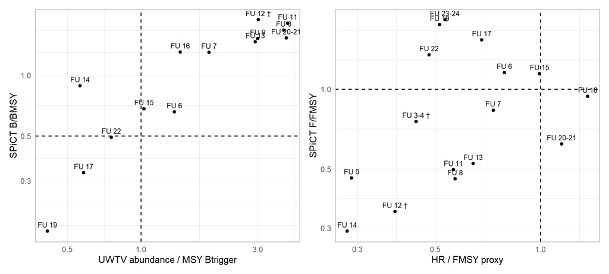

Figure 5: Terminal status from SPiCT against the Category 1 ratios. Lines: status thresholds (SPiCT 0.5 BMSY and FMSY; Category 1 MSY Btrigger and FMSY proxy). Off-diagonal quadrants are disagreements.

```r
p1 <- cmp |> filter(!is.na(ices_B)) |>
  ggplot(aes(ices_B, spict_BBmsy, label = FU)) +
  geom_hline(yintercept = 0.5, linetype = 2) + geom_vline(xintercept = 1, linetype = 2) +
  geom_point() + geom_text(size = 3, vjust = -0.7) +
  scale_x_log10() + scale_y_log10() +
  labs(x = "UWTV abundance / MSY Btrigger", y = "SPiCT B/BMSY") + report_theme
p2 <- cmp |> filter(!is.na(ices_F)) |>
  ggplot(aes(ices_F, spict_FFmsy, label = FU)) +
  geom_hline(yintercept = 1, linetype = 2) + geom_vline(xintercept = 1, linetype = 2) +
  geom_point() + geom_text(size = 3, vjust = -0.7) +
  scale_x_log10() + scale_y_log10() +
  labs(x = "HR / FMSY proxy", y = "SPiCT F/FMSY") + report_theme
p1 + p2
```

## 5.1 Catch advice

ICES Category 1 advice is total catch (landings plus all discards, including the surviving ones). SPiCT’s catch is dead removals, so the SPiCT advice (ICES MSY rule, 35th percentile) is converted to total catch with the recent discard rate and discard survival.

```r
adv <- bind_rows(lapply(ok, function(s) S[[s]]$advice |> mutate(stock = s, FU = lab(s)))) |>
  mutate(FU = factor(FU, fu_levels))
```

```r
adv |> arrange(FU) |>
  transmute(FU, `SPiCT dead removals (t)` = round(spict_catch_dead),
            `SPiCT comparable (t)` = round(spict_comparable),
            `ICES advice (t)` = round(ices_advice),
            `Advice type` = ices_advice_type,
            `SPiCT / ICES` = round(ratio_spict_ices, 2),
            `Previous ICES advice (t)` = round(ices_advice_prev),
            DOI = ices_advice_doi) |>
  kbl(caption = paste0("Catch advice for ", settings$advice_year, ": SPiCT (ICES MSY rule, 35th percentile), converted to the advice type (total catch, or landings), vs the published ICES advice. FU 13: sum of the Clyde and Jura advice.")) |>
  kable_styling(bootstrap_options = c("striped", "condensed"), font_size = 10)
```

Catch advice for 2027: SPiCT (ICES MSY rule, 35th percentile), converted to the advice type (total catch, or landings), vs the published ICES advice. FU 13: sum of the Clyde and Jura advice.

| FU | SPiCT dead removals (t) | SPiCT comparable (t) | ICES advice (t) | Advice type | SPiCT / ICES | Previous ICES advice (t) | DOI |
| --- | --- | --- | --- | --- | --- | --- | --- |
| FU 3-4 † | 10880 | 11325 | 21469 | Catches | 0.53 | 19273 | https://doi.org/10.17895/ices.advice.3093222 |
| FU 6 | 2210 | 2246 | 2428 | Catches | 0.92 | 2176 | https://doi.org/10.17895/ices.advice.30932237 |
| FU 7 | 8077 | 8093 | 12022 | Catches | 0.67 | 11559 | https://doi.org/10.17895/ices.advice.30932240 |
| FU 8 | 3949 | 3989 | 3963 | Catches | 1.01 | 3186 | https://doi.org/10.17895/ices.advice.30932243 |
| FU 9 | 1866 | 1874 | 2819 | Catches | 0.66 | 2989 | https://doi.org/10.17895/ices.advice.30932246 |
| FU 11 | 5976 | 6036 | 6149 | Catches | 0.98 | 5971 | https://doi.org/10.17895/ices.advice.30932174 |
| FU 12 † | 7850 | 7925 | 9265 | Catches | 0.86 | 9603 | https://doi.org/10.17895/ices.advice.30932177 |
| FU 13 | 7779 | 7927 | 5980 | Catches | 1.33 | 6080 | https://doi.org/10.17895/ices.advice.30932183 |
| FU 14 | 694 | 697 | 252 | Catches | 2.77 | 304 | https://doi.org/10.17895/ices.advice.30932186 |
| FU 15 | 6270 | 6357 | 8544 | Catches | 0.74 | 6493 | https://doi.org/10.17895/ices.advice.30932189 |
| FU 16 | 2453 | 2453 | 2084 | Catches | 1.18 | 2169 | https://doi.org/10.17895/ices.advice.30932192 |
| FU 17 | 163 | 169 | 285 | Catches | 0.59 | 288 | https://doi.org/10.17895/ices.advice.30932198 |
| FU 19 | 0 | 0 | 140 | Catches | 0.00 | 357 | https://doi.org/10.17895/ices.advice.30932201 |
| FU 20-21 | 4128 | 4209 | 2863 | Catches | 1.47 | 3171 | https://doi.org/10.17895/ices.advice.30932204 |
| FU 22 | 1088 | 1128 | 1589 | Catches | 0.71 | 2252 | https://doi.org/10.17895/ices.advice.30932207 |
| FU 23-24 | 0 | 0 | 1586 | Landings | 0.00 | 4014 | https://doi.org/10.17895/ices.advice.27202737 |

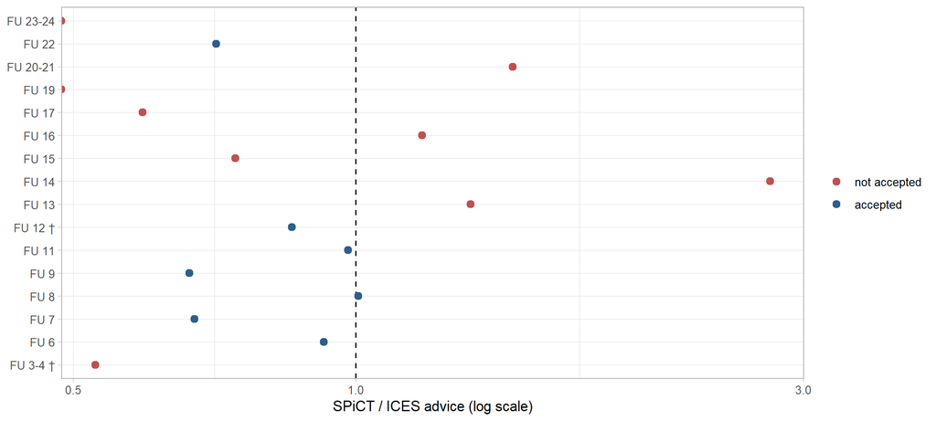

Figure 6: Ratio of SPiCT advice (total-catch equivalent) to ICES advice. Colour: whether the SPiCT assessment passes all acceptance criteria.

```r
adv |> left_join(acc_n |> select(FU, accepted), by = "FU") |>
  ggplot(aes(ratio_spict_ices, FU, colour = accepted)) +
  geom_vline(xintercept = 1, linetype = 2) + geom_point(size = 2.5) +
  scale_x_log10() + scale_colour_manual(values = c(`TRUE` = "#2C5F8A", `FALSE` = "#C0504D"),
                                        labels = c(`TRUE` = "accepted", `FALSE` = "not accepted"), name = NULL) +
  labs(x = "SPiCT / ICES advice (log scale)", y = NULL) + report_theme
```

# 6 Robustness to configuration choices

```r
sens <- bind_rows(lapply(ok, function(s) if (!is.null(S[[s]]$sensitivity)) S[[s]]$sensitivity |> mutate(stock = s))) |>
  mutate(FU = factor(lab(stock), fu_levels))
sens_sum <- sens |> group_by(FU) |>
  # flips first: `converged` is still the logical run flag here (it is overwritten by its count below)
  summarise(B_status_flips = n_distinct(BBmsy[converged] >= settings$btrigger_bmsy) > 1,
            F_status_flips = n_distinct(FFmsy[converged] <= 1) > 1,
            B_flip_runs = paste(label[converged & (BBmsy >= settings$btrigger_bmsy) != (BBmsy[label == "Base"][1] >= settings$btrigger_bmsy)], collapse = "; "),
            F_flip_runs = paste(label[converged & (FFmsy <= 1) != (FFmsy[label == "Base"][1] <= 1)], collapse = "; "),
            runs = n(), converged = sum(converged),
            B_min = min(BBmsy, na.rm = TRUE), B_max = max(BBmsy, na.rm = TRUE),
            F_min = min(FFmsy, na.rm = TRUE), F_max = max(FFmsy, na.rm = TRUE), .groups = "drop") |>
  relocate(B_status_flips, F_status_flips, B_flip_runs, F_flip_runs, .after = last_col())
```

Across the sensitivity runs, the stock-size classification (relative to 0.5 BMSY) changes in 4 of 16 stocks. The fishing-pressure classification (relative to FMSY) changes in 8.

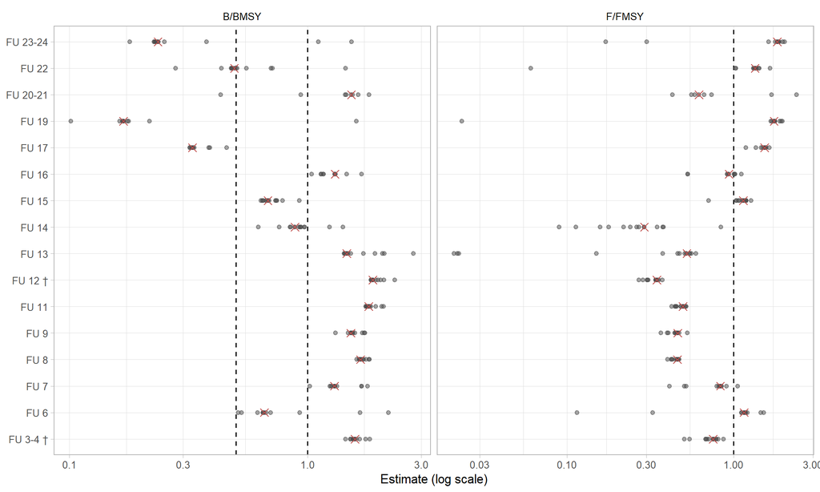

Figure 7: Terminal B/BMSY and F/FMSY across sensitivity runs (points) and base run (cross).

```r
sens |> filter(converged) |>
  select(FU, label, BBmsy, FFmsy) |>
  pivot_longer(c(BBmsy, FFmsy)) |>
  mutate(name = recode(name, BBmsy = "B/BMSY", FFmsy = "F/FMSY")) |>
  ggplot(aes(value, FU)) +
  geom_vline(data = tibble(name = c("B/BMSY", "B/BMSY", "F/FMSY"), x = c(0.5, 1, 1)), aes(xintercept = x), linetype = 2) +
  geom_point(alpha = 0.5, colour = "grey30") +
  geom_point(data = \(x) filter(x, label == "Base"), shape = 4, size = 3, colour = "#C0504D") +
  facet_wrap(~name, scales = "free_x") + scale_x_log10() +
  labs(x = "Estimate (log scale)", y = NULL) + report_theme
```

## 6.1 Index observation error

UWTV confidence intervals capture sampling variance only. Bias and variance from burrow identification, edge effects, the one-burrow-one-animal assumption and changes in survey design are not included, so they are likely too narrow. Three runs widen the index error relative to the base (prior median = mean UWTV CV): the prior median at 2 and 3 times the CV, and no prior.

```r
cv_tab <- tibble(stock = ok, cv = vapply(ok, \(s) S[[s]]$meta$mean_index_cv, numeric(1))) |>
  mutate(FU = factor(lab(stock), fu_levels))
sdi_runs <- c("Base", "sdi prior x2", "sdi prior x3", "sdi prior off")
sdi_tab <- sens |> filter(label %in% sdi_runs) |>
  left_join(cv_tab |> select(stock, cv), by = "stock") |>
  group_by(FU) |>
  mutate(base_B = BBmsy[label == "Base"][1], base_F = FFmsy[label == "Base"][1]) |>
  ungroup() |>
  mutate(sdi_cv = sdi / cv, dB = BBmsy / base_B - 1, dF = FFmsy / base_F - 1)
x3 <- sdi_tab |> filter(label == "sdi prior x3", converged)
base_sdi <- sdi_tab |> filter(label == "Base", converged)
```

In the base runs the estimated sdi is a median of 1.7 times the UWTV CV (range 1.0–6.9). With the prior at 3 × CV, 15 of 16 runs converged. Their terminal B/BMSY moves by a median of 2 % from the base run (maximum 13 %), and F/FMSY by a median of 2 % (maximum 17 %).

```r
sdi_tab |>
  transmute(FU, run = label, converged, `UWTV CV` = round(cv, 3), sdi = round(sdi, 3),
            `sdi / CV` = round(sdi_cv, 1), `B/BMSY` = round(BBmsy, 2),
            `change B` = sprintf("%+.0f %%", 100 * dB), `F/FMSY` = round(FFmsy, 2),
            `change F` = sprintf("%+.0f %%", 100 * dF), `CI B (log10)` = round(ci_B, 2),
            `OSA fails` = osa_fail) |>
  mutate(run = factor(run, sdi_runs)) |> arrange(FU, run) |>
  kbl(caption = "Base and index-error runs: estimated sdi relative to the UWTV CV and change in terminal status.") |>
  kable_styling(bootstrap_options = c("striped", "condensed"), font_size = 10) |>
  scroll_box(height = "450px")
```

Base and index-error runs: estimated sdi relative to the UWTV CV and change in terminal status.

| FU | run | converged | UWTV CV | sdi | sdi / CV | B/BMSY | change B | F/FMSY | change F | CI B (log10) | OSA fails |
| --- | --- | --- | --- | --- | --- | --- | --- | --- | --- | --- | --- |
| FU 3-4 † | Base | TRUE | 0.052 | 0.081 | 1.6 | 1.58 | +0 % | 0.75 | +0 % | 0.61 | 0 |
| FU 3-4 † | sdi prior x2 | TRUE | 0.052 | 0.124 | 2.4 | 1.55 | -2 % | 0.71 | -6 % | 0.67 | 0 |
| FU 3-4 † | sdi prior x3 | TRUE | 0.052 | 0.150 | 2.9 | 1.55 | -2 % | 0.68 | -10 % | 0.70 | 0 |
| FU 3-4 † | sdi prior off | TRUE | 0.052 | 0.146 | 2.8 | 1.55 | -2 % | 0.69 | -9 % | 0.69 | 0 |
| FU 6 | Base | TRUE | 0.050 | 0.076 | 1.5 | 0.66 | +0 % | 1.15 | +0 % | 0.43 | 0 |
| FU 6 | sdi prior x2 | TRUE | 0.050 | 0.098 | 1.9 | 0.65 | -1 % | 1.18 | +2 % | 0.44 | 0 |
| FU 6 | sdi prior x3 | TRUE | 0.050 | 0.109 | 2.2 | 0.65 | -1 % | 1.19 | +3 % | 0.45 | 0 |
| FU 6 | sdi prior off | TRUE | 0.050 | 0.097 | 1.9 | 0.65 | -1 % | 1.17 | +2 % | 0.44 | 0 |
| FU 7 | Base | TRUE | 0.072 | 0.070 | 1.0 | 1.29 | +0 % | 0.83 | +0 % | 0.48 | 0 |
| FU 7 | sdi prior x2 | TRUE | 0.072 | 0.102 | 1.4 | 1.26 | -3 % | 0.84 | +1 % | 0.50 | 0 |
| FU 7 | sdi prior x3 | TRUE | 0.072 | 0.118 | 1.6 | 1.24 | -4 % | 0.85 | +2 % | 0.51 | 0 |
| FU 7 | sdi prior off | TRUE | 0.072 | 0.065 | 0.9 | 1.30 | +0 % | 0.83 | -0 % | 0.48 | 0 |
| FU 8 | Base | TRUE | 0.093 | 0.154 | 1.7 | 1.67 | +0 % | 0.46 | +0 % | 0.26 | 0 |
| FU 8 | sdi prior x2 | TRUE | 0.093 | 0.168 | 1.8 | 1.65 | -1 % | 0.46 | -0 % | 0.26 | 0 |
| FU 8 | sdi prior x3 | TRUE | 0.093 | 0.176 | 1.9 | 1.65 | -1 % | 0.46 | -0 % | 0.26 | 0 |
| FU 8 | sdi prior off | TRUE | 0.093 | 0.165 | 1.8 | 1.66 | -1 % | 0.46 | -0 % | 0.26 | 0 |
| FU 9 | Base | TRUE | 0.143 | 0.246 | 1.7 | 1.52 | +0 % | 0.46 | +0 % | 0.40 | 0 |
| FU 9 | sdi prior x2 | TRUE | 0.143 | 0.264 | 1.8 | 1.53 | +0 % | 0.46 | -0 % | 0.40 | 0 |
| FU 9 | sdi prior x3 | TRUE | 0.143 | 0.275 | 1.9 | 1.53 | +1 % | 0.46 | -1 % | 0.40 | 0 |
| FU 9 | sdi prior off | TRUE | 0.143 | 0.261 | 1.8 | 1.53 | +0 % | 0.46 | -0 % | 0.40 | 0 |
| FU 11 | Base | TRUE | 0.083 | 0.147 | 1.8 | 1.81 | +0 % | 0.50 | +0 % | 0.24 | 0 |
| FU 11 | sdi prior x2 | TRUE | 0.083 | 0.161 | 1.9 | 1.78 | -1 % | 0.50 | +0 % | 0.24 | 0 |
| FU 11 | sdi prior x3 | TRUE | 0.083 | 0.170 | 2.1 | 1.77 | -2 % | 0.50 | +1 % | 0.24 | 0 |
| FU 11 | sdi prior off | TRUE | 0.083 | 0.161 | 1.9 | 1.78 | -1 % | 0.50 | +0 % | 0.24 | 0 |
| FU 12 † | Base | TRUE | 0.104 | 0.276 | 2.7 | 1.88 | +0 % | 0.35 | +0 % | 0.25 | 0 |
| FU 12 † | sdi prior x2 | TRUE | 0.104 | 0.293 | 2.8 | 1.87 | -0 % | 0.34 | -1 % | 0.25 | 0 |
| FU 12 † | sdi prior x3 | TRUE | 0.104 | 0.303 | 2.9 | 1.87 | -1 % | 0.34 | -1 % | 0.25 | 0 |
| FU 12 † | sdi prior off | TRUE | 0.104 | 0.302 | 2.9 | 1.87 | -1 % | 0.34 | -1 % | 0.25 | 0 |
| FU 13 | Base | TRUE | 0.074 | 0.139 | 1.9 | 1.46 | +0 % | 0.52 | +0 % | 0.25 | 0 |
| FU 13 | sdi prior x2 | TRUE | 0.074 | 0.156 | 2.1 | 1.44 | -2 % | 0.54 | +4 % | 0.26 | 0 |
| FU 13 | sdi prior x3 | TRUE | 0.074 | 0.167 | 2.3 | 1.42 | -3 % | 0.56 | +7 % | 0.28 | 0 |
| FU 13 | sdi prior off | TRUE | 0.074 | 0.158 | 2.1 | 1.43 | -2 % | 0.55 | +4 % | 0.27 | 0 |
| FU 14 | Base | TRUE | 0.101 | 0.143 | 1.4 | 0.89 | +0 % | 0.29 | +0 % | 0.47 | 0 |
| FU 14 | sdi prior x2 | TRUE | 0.101 | 0.175 | 1.7 | 0.93 | +5 % | 0.26 | -10 % | 0.48 | 0 |
| FU 14 | sdi prior x3 | TRUE | 0.101 | 0.196 | 2.0 | 0.97 | +10 % | 0.24 | -17 % | 0.50 | 0 |
| FU 14 | sdi prior off | TRUE | 0.101 | 0.166 | 1.6 | 0.92 | +4 % | 0.27 | -7 % | 0.48 | 0 |
| FU 15 | Base | TRUE | 0.030 | 0.061 | 2.0 | 0.68 | +0 % | 1.14 | +0 % | 0.76 | 1 |
| FU 15 | sdi prior x2 | TRUE | 0.030 | 0.077 | 2.6 | 0.65 | -4 % | 1.19 | +4 % | 0.67 | 1 |
| FU 15 | sdi prior x3 | TRUE | 0.030 | 0.086 | 2.9 | 0.65 | -5 % | 1.19 | +5 % | 0.64 | 1 |
| FU 15 | sdi prior off | TRUE | 0.030 | 0.085 | 2.9 | 0.65 | -5 % | 1.19 | +4 % | 0.64 | 1 |
| FU 16 | Base | TRUE | 0.039 | 0.052 | 1.3 | 1.30 | +0 % | 0.94 | +0 % | 0.85 | 1 |
| FU 16 | sdi prior x2 | TRUE | 0.039 | 0.092 | 2.4 | 1.17 | -10 % | 1.00 | +7 % | 0.66 | 1 |
| FU 16 | sdi prior x3 | TRUE | 0.039 | 0.112 | 2.9 | 1.14 | -13 % | 1.02 | +9 % | 0.65 | 1 |
| FU 16 | sdi prior off | TRUE | 0.039 | 0.108 | 2.8 | 1.14 | -12 % | 1.02 | +8 % | 0.65 | 1 |
| FU 17 | Base | TRUE | 0.052 | 0.176 | 3.4 | 0.33 | +0 % | 1.53 | +0 % | 0.47 | 0 |
| FU 17 | sdi prior x2 | TRUE | 0.052 | 0.198 | 3.8 | 0.33 | -0 % | 1.54 | +1 % | 0.47 | 0 |
| FU 17 | sdi prior x3 | TRUE | 0.052 | 0.212 | 4.0 | 0.33 | -0 % | 1.54 | +1 % | 0.48 | 0 |
| FU 17 | sdi prior off | TRUE | 0.052 | 0.223 | 4.3 | 0.33 | -0 % | 1.54 | +1 % | 0.48 | 0 |
| FU 19 | Base | TRUE | 0.141 | 0.215 | 1.5 | 0.17 | +0 % | 1.75 | +0 % | 0.45 | 0 |
| FU 19 | sdi prior x2 | TRUE | 0.141 | 0.242 | 1.7 | 0.17 | +0 % | 1.76 | +0 % | 0.46 | 0 |
| FU 19 | sdi prior x3 | TRUE | 0.141 | 0.260 | 1.8 | 0.17 | +1 % | 1.76 | +1 % | 0.46 | 0 |
| FU 19 | sdi prior off | TRUE | 0.141 | 0.234 | 1.7 | 0.17 | +0 % | 1.76 | +0 % | 0.46 | 0 |
| FU 20-21 | Base | TRUE | 0.045 | 0.309 | 6.9 | 1.53 | +0 % | 0.62 | +0 % | 0.36 | 1 |
| FU 20-21 | sdi prior x2 | FALSE | 0.045 | NA | NA | NA | NA % | NA | NA % | NA | NA |
| FU 20-21 | sdi prior x3 | FALSE | 0.045 | NA | NA | NA | NA % | NA | NA % | NA | NA |
| FU 20-21 | sdi prior off | FALSE | 0.045 | NA | NA | NA | NA % | NA | NA % | NA | NA |
| FU 22 | Base | TRUE | 0.060 | 0.146 | 2.4 | 0.49 | +0 % | 1.35 | +0 % | 0.82 | 0 |
| FU 22 | sdi prior x2 | TRUE | 0.060 | 0.163 | 2.7 | 0.48 | -2 % | 1.36 | +1 % | 0.81 | 0 |
| FU 22 | sdi prior x3 | TRUE | 0.060 | 0.174 | 2.9 | 0.48 | -2 % | 1.36 | +1 % | 0.81 | 0 |
| FU 22 | sdi prior off | TRUE | 0.060 | 0.173 | 2.9 | 0.48 | -2 % | 1.36 | +1 % | 0.81 | 0 |
| FU 23-24 | Base | TRUE | 0.089 | 0.185 | 2.1 | 0.23 | +0 % | 1.83 | +0 % | 0.47 | 0 |
| FU 23-24 | sdi prior x2 | TRUE | 0.089 | 0.214 | 2.4 | 0.23 | -1 % | 1.84 | +1 % | 0.50 | 0 |
| FU 23-24 | sdi prior x3 | TRUE | 0.089 | 0.234 | 2.6 | 0.23 | -2 % | 1.86 | +2 % | 0.51 | 0 |
| FU 23-24 | sdi prior off | TRUE | 0.089 | 0.225 | 2.5 | 0.23 | -2 % | 1.85 | +1 % | 0.51 | 0 |

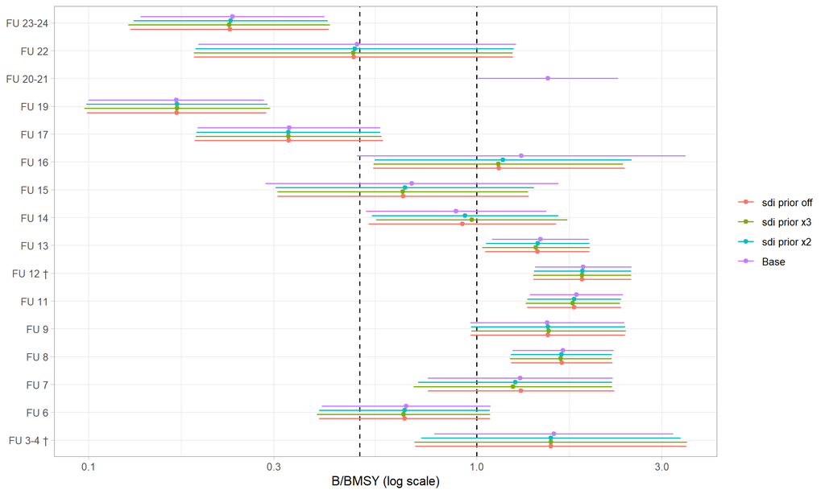

Figure 8: Terminal B/BMSY (95 % CI) in the base run and with wider index observation error.

```r
sdi_tab |> filter(converged) |>
  mutate(label = factor(label, rev(sdi_runs))) |>
  ggplot(aes(BBmsy, FU, colour = label)) +
  geom_vline(xintercept = c(0.5, 1), linetype = 2) +
  geom_pointrange(aes(xmin = BBmsy_lo, xmax = BBmsy_hi), position = position_dodge(width = 0.6), size = 0.2) +
  scale_x_log10() + labs(x = "B/BMSY (log scale)", y = NULL, colour = NULL) + report_theme
```

## 6.2 All runs

```r
sens_sum |> arrange(FU) |>
  mutate(across(c(B_min, B_max, F_min, F_max), ~round(.x, 2)),
         across(c(B_status_flips, F_status_flips), ~ifelse(.x, "YES", "no"))) |>
  kbl(caption = "Range of terminal estimates across sensitivity runs and whether the status classification changes.") |>
  kable_styling(bootstrap_options = c("striped", "condensed"), font_size = 11)
```

Range of terminal estimates across sensitivity runs and whether the status classification changes.

| FU | runs | converged | B_min | B_max | F_min | F_max | B_status_flips | F_status_flips | B_flip_runs | F_flip_runs |
| --- | --- | --- | --- | --- | --- | --- | --- | --- | --- | --- |
| FU 3-4 † | 14 | 14 | 1.44 | 1.82 | 0.51 | 0.87 | no | no |  |  |
| FU 6 | 14 | 12 | 0.51 | 2.18 | 0.12 | 1.52 | no | YES |  | r prior x0.5; Biomass index (N x mean weight) |
| FU 7 | 14 | 14 | 1.02 | 1.78 | 0.41 | 1.06 | no | YES |  | B0/K 0.25 |
| FU 8 | 14 | 14 | 1.61 | 1.82 | 0.40 | 0.47 | no | no |  |  |
| FU 9 | 14 | 14 | 1.31 | 1.74 | 0.37 | 0.53 | no | no |  |  |
| FU 11 | 14 | 14 | 1.76 | 2.09 | 0.43 | 0.52 | no | no |  |  |
| FU 12 † | 14 | 14 | 1.85 | 2.32 | 0.27 | 0.37 | no | no |  |  |
| FU 13 | 14 | 14 | 1.42 | 2.79 | 0.02 | 0.60 | no | no |  |  |
| FU 14 | 14 | 14 | 0.62 | 1.41 | 0.09 | 0.84 | no | no |  |  |
| FU 15 | 14 | 14 | 0.64 | 0.92 | 0.71 | 1.28 | no | YES |  | B0/K 0.25 |
| FU 16 | 14 | 10 | 1.04 | 1.69 | 0.53 | 1.11 | no | YES |  | r prior x1.5; sdi prior off; sdi prior x2; sdi prior x3 |
| FU 17 | 14 | 13 | 0.32 | 0.46 | 1.18 | 1.64 | no | no |  |  |
| FU 19 | 14 | 14 | 0.10 | 1.61 | 0.02 | 1.97 | YES | YES | Fox shape (n = 1.01 fixed) | Fox shape (n = 1.01 fixed) |
| FU 20-21 | 14 | 8 | 0.43 | 1.81 | 0.43 | 2.39 | YES | YES | B0/K 0.25 | B0/K 0.25; Catch from first index year |
| FU 22 | 14 | 14 | 0.28 | 1.44 | 0.06 | 1.66 | YES | YES | r prior x0.5; r prior sd x2; B0/K 0.75; Shape n estimated (prior 2, sd 0.5); Fox shape (n = 1.01 fixed); Biomass index (N x mean weight) | Biomass index (N x mean weight) |
| FU 23-24 | 14 | 14 | 0.18 | 1.53 | 0.17 | 2.03 | YES | YES | r prior x1.5; Fox shape (n = 1.01 fixed) | r prior x1.5; Fox shape (n = 1.01 fixed) |

# 7 Caveats

- † Stocks with a B0/K prior tuned for convergence: their sensitivity runs vary around the tuned base, so the “B0/K 0.75” run repeats the base run. The generic configuration (B0/K 0.5) is reported in the stock documents and in the scope table, not as a sensitivity run.
- The UWTV index counts animals, while SPiCT models biomass. The “Biomass index” sensitivity run tests the effect of mean-weight changes, using the mean weight of the removals.
- Priors are generic: r is a *Nephrops* meta-analysis value from the FU32 template, and B0/K is weakly informative. Where the posterior/prior SD ratio is near 1, the estimate reflects the prior.
- UWTV CVs measure sampling precision only and are likely too narrow. `sdi` is estimated with a prior centred on the mean CV, with SD 0.5 (wider than in FU32), and tested with 2 × and 3 × the CV and with no prior (section “Index observation error”).
- Discards before the first year of discard data are imputed.
- Short UWTV series (FU 3-4, 16, 20-21, 23-24) have little contrast.

# 8 Reproducibility

Inputs: SAG 2026 records cached in `data/sag/`, ICES advice in `data/asd/`. spict 1.3.9. Stock documents in `stock/<stock>/`. Rerun with `Rscript R/render_all.R`.

# References

Hurtado-Ferro, Felipe et al. 2015. “Looking in the Rear-View Mirror: Bias and Retrospective Patterns in Integrated, Age-Structured Stock Assessment Models.” *ICES Journal of Marine Science* 72: 99–110. https://doi.org/10.1093/icesjms/fsu198.

ICES. 2026. “Working Group for the Assessment of Nephrops Stocks (WGNEPH).” ICES Scientific Reports 7:51. International Council for the Exploration of the Sea. https://doi.org/10.17895/ices.pub.30477911.